# A brief introduction to Julia

David A. W. Barton

## Aims of this session

- This is not a tutorial!
- Benefits (and disadvantages) of Julia
  - A little heavy on differential equations…
  - …but it’s not just differential equations
- Cool stuff / packages I use

Key question: **should you try it?**

## Follow along

If you want to try some of the examples as we go along, this presentation is available from https://engmaths.github.io/julia-intro

[figure not shown]

QR Code for the slides

## Setting up Julia

I work from the command line, so there might be other (easier?) ways

1. Install the Julia version manager: [JuliaUp](https://julialang.org/install/)
2. Install Julia v1.10 (LTS): `juliaup add lts`
   - Latest is Julia v1.12 but not all packages updated yet
3. Run Julia: `julia`

VS Code has a Julia plugin — *probably the best for most people* — though other editors that know about Language Server Protocol also work

## Setting up Julia — packages

Julia has a built in package manager (no more Conda / Pip / Pixi / uv 😁)

1. At the Julia command line press `]` to activate Pkg mode
2. Type `add <packagename1> <packagename2> ...`

Note that you have a *global* environment and *project* environments; avoid putting too much in global

Project environments mean everything is reproducible!

## What is Julia (by Claude)

Julia is a high-level, high-performance programming language designed for technical computing. It combines the ease of use of languages like Python and R with the speed of C and Fortran.

## Key features of Julia (by Claude)

- Dynamic typing with optional type annotations
- Built-in support for parallel and distributed computing
- A rich ecosystem for scientific computing, data science, and machine learning
- Just-in-time (JIT) compilation for fast execution
- Multiple dispatch as a core programming paradigm

## Why do I use it?

Originally because

- It’s fast!
  - Though the compilation time is a pain…

Now because

- It’s still fast — can incrementally improve your code
- It’s elegant and expressive
- There is an helpful academic community around it
- Differential equations libraries are second to none

## Diving straight in — writing an ODE

A (trivial) mass-spring-damper system

$$x'' + cx' + kx = \Gamma\sin(\omega t)$$

```julia
using OrdinaryDiffEq  # `using DiffEq` for the kitchen sink...

# As a single line function
msd(u, p, t) = [u[2], -p.c * u[2] - p.k * u[1] + p.Γ * sin(p.ω * t)]

# Or equivalently
function msd(u, p, t)
    return [
        u[2],
        -p.c * u[2] - p.k * u[1] + p.Γ * sin(p.ω*t)
    ]
end
```

## Diving straight in — solving an ODE

```julia
using OrdinaryDiffEq, CairoMakie

# As a single line function
msd(u, p, t) = [u[2], -p.c * u[2] - p.k * u[1] + p.Γ * sin(p.ω * t)]

u₀ = [0.0, 0.0]  # an array (homogeneous storage; can be huge)
t = (0.0, 10.0)  # a tuple (heterogeneous storage; should be small)
p = (c=0.1, k=1, Γ=1, ω=0.5)  # a named tuple (unicode can be nice)

prob = ODEProblem(msd, u₀, t, p)  # or DDEProblem/SDEProblem/...
sol = solve(prob, Tsit5())  # Tsit5 is roughly equivalent to ode45
plot(sol)  # a plotting receipe
```

## Diving straight in — plotting an ODE

[figure not shown]

## Standard functionality

Has all the same functionality as MATLAB ODE solvers

- Event detection
- Control over solution output
- Interpolation of solutions
- Stepsize control

Plus

- Almost every ODE/DAE/DDE/SDE solver ever made
- Fine-grained control over the internals (if desired)

## If you really want fast code

```julia
using StaticArrays

msd(u, p, t) = SVector(u[2], -p.c * u[2] - p.k * u[1] + p.Γ * sin(p.ω * t))

static_u₀ = SVector(0.0, 0.0)  # a static array (fixed size; very fast)

static_prob = ODEProblem(msd, static_u₀, t, p)
@btime static_sol = solve(static_prob, Tsit5())
# -> 11.334 μs (112 allocations: 24.30 KiB)
```

Static arrays are good for small (<100 elements) vectors

Can make compile times much longer if overused! *Code gets recompiled whenever sizes change*

## Performance comparison

With identical tolerances:

- Julia (fast): 11 μs (88,230 runs per second)
- Julia (simple): 93 μs (10,661 runs per second)
- MATLAB (ode45): 151 μs (6,618 runs per second)
- Python (SciPy): 1,590 μs (629 runs per second) (!!!)

## Take away 1

With Julia you can prototype approaches with simple code…

…and iteratively improve to increase speed *(if needed)*

## Composing with other packages

Julia is highly composable — want more precision? Use `DoubleFloats.jl` or `MultiFloats.jl`

```julia
using DoubleFloats

prec_u₀ = Double64[0.0, 0.0]
prec_t = map(Double64, (0.0, 80.0))
prec_p = map(Double64, (c=0.1, k=1, Γ=1, ω=0.5))

prec_prob = ODEProblem(msd, prec_u₀, prec_t, prec_p)
prec_sol = solve(prec_prob, Tsit5())

println("Final solution at u(80) = $(prec_sol.u[end])")
```

```
Final solution at u(80) = DoubleFloats.Double64[1.05953114871073252658181011056407675, -4.06409596667339489873462293556085961e-01]
```

## Still (quite) fast

```julia
using BenchmarkTools

# Original problem

@btime sol = solve(prob, Tsit5())
# -> 93.792 μs (6744 allocations: 534.91 KiB)

# Higher precision problem

@btime prec_sol = solve(prec_prob, Tsit5()) ;
# -> 338.125 μs (8192 allocations: 714.27 KiB)
```

Timings on an M4 MacBook Pro

(Though I didn’t change the ODE solver tolerances, so not actually more accurate 🙃)

## Make your life easier by naming things

Labelling variables can make code less error prone

```julia
using ComponentArrays

function msd!(dudt, u, p, t; external = 0)
    dudt.x = u.dx
    dudt.dx = -p.c * u.dx - p.k * u.x + p.Γ * sin(p.ω * t) + external
    return dudt
end

named_u₀ = ComponentVector(x = 0.0, dx = 0.0)

named_prob = ODEProblem(msd!, named_u₀, t, p)
@btime named_sol = solve(named_prob, Tsit5())
# -> 22.417 μs (826 allocations: 72.89 KiB)
```

A `ComponentVector` is just a vector with names for the components - very useful for nested systems

## Building with components

Couple two mass-spring-damper systems together

$$x'' + c_1x' + k_1x + \alpha(y - x) = \Gamma_1\sin(\omega_1 t)$$

$$y'' + c_2y' + k_2y + \alpha(x - y) = \Gamma_2\sin(\omega_2 t)$$

## Separation of concerns

```julia
function system!(dudt, u, p, t)
    msd!(dudt.sys1, u.sys1, p.sys1, t;
        external = -p.alpha * (u.sys2.x - u.sys1.x))
    msd!(dudt.sys2, u.sys2, p.sys2, t;
        external = -p.alpha * (u.sys1.x - u.sys2.x))
    return dudt
end

p = (sys1 = (c=0.1, k=1, Γ=1, ω=0.5),
     sys2 = (c=0.1, k=1.1, Γ=0, ω=0.5),
     alpha = 0.1)
u = ComponentVector(sys1 = ComponentVector(x=0.0, dx=0.0),
                    sys2 = ComponentVector(x=0.0, dx=0.0))

prob = ODEProblem(system!, u, (0.0, 80.0), p)
@btime sol = solve(prob, Tsit5())
# -> 24.167 μs (862 allocations: 87.53 KiB)
```

## Separation of concerns

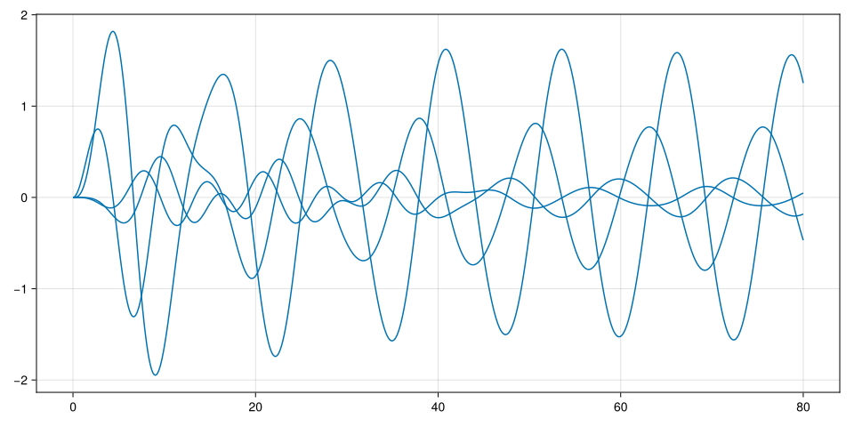

## Take away 2

Julia enables robust, readable code while retaining speed through zero-cost abstractions

## Macros re-write code for you

Julia’s macros enable Domain Specific Languages (DSLs)

```julia
using ModelingToolkit

@mtkmodel RCModel begin
    @description """A circuit with a constant voltage source, resistor
        and capacitor connected in series."""
    @components begin
        resistor = Resistor(R = 1.0)
        capacitor = Capacitor(C = 1.0)
        source = ConstantVoltage(V = 1.0)
        ground = Ground()
    end
    @equations begin
        connect(source.p, resistor.p)  # p = positive terminal
        connect(resistor.n, capacitor.p)  # n = negative terminal
        connect(capacitor.n, source.n)
        connect(capacitor.n, ground.g)
    end
end
```

## Components written as equations

```julia
@mtkmodel Resistor begin
    @extend OnePort()
    @parameters begin
        R = 1.0  # Sets the default resistance
    end
    @equations begin
        v ~ i * R  # algebraic equation
    end
end
```

```julia
@mtkmodel Capacitor begin
    @extend OnePort()
    @parameters begin
        C = 1.0  # Sets the default capacitance
    end
    @equations begin
        D(v) ~ i / C  # differential equation
    end
end
```

## Automatic model simplification

Full code in the [acausal modelling example](https://docs.sciml.ai/ModelingToolkit/dev/tutorials/acausal_components/)

Build the model to create the equations:

```julia
@mtkcompile rc_model = RCModel(resistor.R = 2.0)
```

$$\begin{align}
\frac{\mathrm{d} \mathtt{capacitor.v}\left( t \right)}{\mathrm{d}t} &= \frac{\mathtt{capacitor.i}\left( t \right)}{\mathtt{capacitor.C}}
\end{align}$$

## Automatic model simplification

```julia
observed(rc_model)
```

$$\begin{align}
\mathtt{capacitor.i}\left( t \right) &= \mathtt{resistor.i}\left( t \right) \\
\mathtt{resistor.i}\left( t \right) &= \frac{\mathtt{resistor.v}\left( t \right)}{\mathtt{resistor.R}} \\
\mathtt{resistor.v}\left( t \right) &= - \mathtt{capacitor.v}\left( t \right) + \mathtt{source.v}\left( t \right) \\
\mathtt{source.v}\left( t \right) &= \mathtt{source.V} \\
\vdots
\end{align}$$

## Other DSLs

- `Catalyst.jl` — create (chemical) reaction networks from simple descriptions (well-used software)
  - Generates corresponding ODEs / SDEs / jump processes depending on requirements

```julia
using Catalyst

sir_model = @reaction_network begin
    b, S + I --> 2I
    k, I --> R
end
```

## Other DSLs

- `SBMLImporter.jl` — import Systems Biology Markup Language models
- `Conductor.jl` — build (biological) neurons from the ground up
- `ModelingToolkitStandardLibrary.jl` — mechanical, electrical, magnetic, and thermal components
- Various commerical offerings through Dyad (JuliaHub)

All integrate with the standard solvers; also integrates FMUs (Functional Mock-up Units) from other languages (e.g., Simulink / Modelica / etc)

## Take away 3

Julia’s macro system means you can express models in convenient forms and then (symbolically) rewrite them for use with standard solvers

## Working with GPUs

For simple usage, just use an appropriate array type, e.g., `CuArray` (CUDA – Nvidia), `MtlArray` (Metal — Apple), `ROCArray` (ROCm — AMD)

Good for massively parallel calculations

```julia
using Metal

A = rand(Float32, 1_000_000)  # large array on CPU
A_mtl = MtlArray(A)  # copy to GPU

# Apply same calculation to each element (CPU)
@btime map(x -> x^2 + sin(x), A)
# -> 3.070 ms (3 allocations: 3.81 MiB)

# Apply same calculation to each element (GPU)
@btime map(x -> x^2 + sin(x), A_mtl)
# -> 26.375 μs (205 allocations: 4.86 KiB)
```

## Scaling on the GPU

Need sufficiently large calculations to make GPU useful

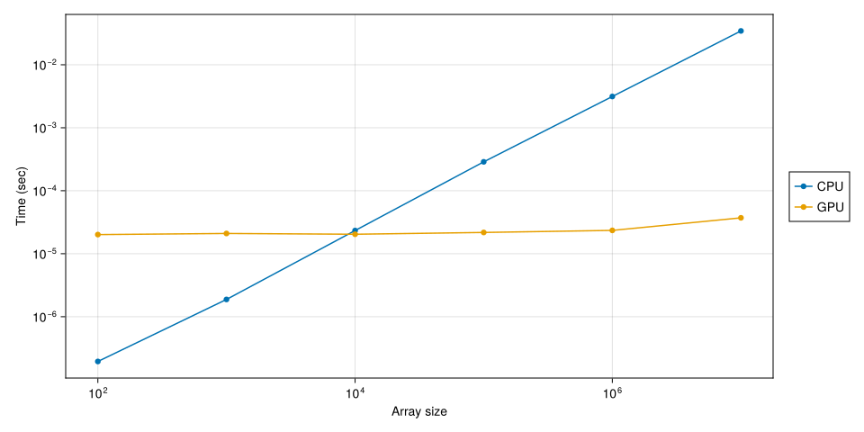

## Large-scale matrix calculations

If you do a lot of large matrix calculations, take a look at [Reactant.jl](https://enzymead.github.io/Reactant.jl/)

- Takes standard Julia code, just add `@compile`
  - *Needs some care in how it’s written!*
- Compiles your code to MLIR (Multi-Level Intermediate Representation)
- Does fancy linear algebra optimisations
- Compiles to CPU/GPU/TPU via XLA
- Can run across multiple nodes

## Take away 4

Easy to use GPUs for massively parallel calculations, though there are some sharp edges…

## But I’ve got a lot of code in Python

or MATLAB / R / C / Rust

No problem, you can keep using it…

```julia
using CondaPkg
CondaPkg.add("seaborn")
using PythonCall, RDatasets

iris = dataset("datasets", "iris")
sns = pyimport("seaborn")
sns.set_theme()
sns.pairplot(pytable(iris), hue="Species")
```

## Interoperability

| Language | Package |
| --- | --- |
| Python | PythonCall.jl |
| MATLAB | MATLAB.jl |
| R | RCall.jl |
| Java | JavaCall.jl |
| C | built in |
| Rust | jlrs |

## Take away 5

Interoperability is excellent (especially for Python)

## Things I don’t have time to mention

- Data manipulation ecosystem (`DataFrames.jl` et al) is great
- Plotting is excellent (`Makie.jl`)
  - Throw a million points to the screen without blinking
- Constrained optimisation interface is best in class (`JuMP.jl`)
- Quite a few people thinking about EdTech (e.g., `Pluto.jl`)
- Great community

## The sharp bits (part 1)

- Error messages are sometimes often hard to read
  - Stack traces get very long with type information
- Debugging is somewhat primitive 🗿
- GPU-based programming can be frustrating
  - Error messages are **really** hard to understand 🤯
- Compiler changes might make your code suddenly become slow 🐢
- Editor support isn’t as sophisticated as other languages

## The sharp bits (part 2)

- Precompiling can be slow (5 min for `OrdinaryDiffEq`?)
- Package churn is probably higher than more mature languages
- Machine learning software stack needs more work
  - Great when it works, but not as polished as PyTorch
- Usual open source-related gripes
  - A few people doing a lot of work
  - PhD student-based packages (i.e., unsupported after a few years)

## Conclusions

- Prototype with simple code and iteratively improve to increase speed *(if needed)*
- Robust, readable code while still being fast (zero-cost abstractions)
- Macros rewrite code for you (plus symbolic rewriting)
- Easy to use GPUs for massively parallel calculations
- Interoperability is excellent (especially for Python)
- **Most packages designed to work together**

## Learning Julia

- Wide selection of tutorials: https://julialang.org/learning/
- Great tutorial from George Datseris (U of Exeter): https://github.com/Datseris/Zero2Hero-JuliaWorkshop

## Notable packages

- [DiffEq ecosystem](https://diffeq.sciml.ai/) — ODEs, SDEs, DDEs, DAEs, etc.
- [ModelingToolkit.jl](https://mtk.sciml.ai/) — Symbolic modelling
- [BifurcationKit.jl](https://bifurcationkit.github.io/BifurcationKitDocs.jl/) — Bifurcation analysis
- [Turing.jl](https://turing.ml/) — Probabilistic programming
- [Lux.jl](https://lux.csail.mit.edu/) & [Reactant.jl](https://enzymead.github.io/Reactant.jl/) — Machine learning
- [Makie.jl](https://makie.org/) — Beautiful plotting/visualisation
- [DataFrames.jl](https://dataframes.juliadata.org/) — Data manipulation
- [JuMP.jl](https://jump.dev/JuMP.jl/stable/) — Optimization